# Section: B – UNIT II

# Q3.a.

Use the Intel Image Classification dataset. (https://www.kaggle.com/datasets/puneet6060/intel-image-classification) (≈25k images, 6 categories like buildings, forest, street). Train a simple CNN classifier (3–4 convolution layers). Submit code, accuracy plots, and test results. In case the training is taking time, then take a small sample of images.

```
Epoch 1, Loss=0.9352, Test Acc=72.57%
Epoch 2, Loss=0.6234, Test Acc=80.73%
Epoch 3, Loss=0.4932, Test Acc=81.47%
Epoch 4, Loss=0.4239, Test Acc=83.53%
Epoch 5, Loss=0.3586, Test Acc=85.57%
```

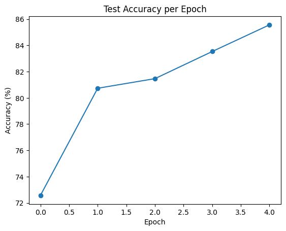

```python
# Simple CNN on Intel Image Classification Dataset
import torch
import torch.nn as nn
import torch.optim as optim
from torch.utils.data import DataLoader
import torchvision
import torchvision.transforms as transforms
import matplotlib.pyplot as plt

# 1. Data transforms
transform = transforms.Compose([
    transforms.Resize((150,150)),   # Resize all images to fixed size
    transforms.ToTensor(),
    transforms.Normalize((0.5,0.5,0.5), (0.5,0.5,0.5)) # normalize RGB channels
])

# 2. Load dataset from Kaggle path
train_data = torchvision.datasets.ImageFolder(root="/kaggle/input/intel-image-classification/seg_train/seg_train", transform=transform)
test_data = torchvision.datasets.ImageFolder(root="/kaggle/input/intel-image-classification/seg_test/seg_test", transform=transform)

train_loader = DataLoader(train_data, batch_size=64, shuffle=True)
test_loader = DataLoader(test_data, batch_size=64, shuffle=False)

# 3. Define a simple CNN
class SimpleCNN(nn.Module):
    def __init__(self):
        super(SimpleCNN, self).__init__()
        self.conv_layers = nn.Sequential(
            nn.Conv2d(3, 32, kernel_size=3, padding=1),
            nn.ReLU(),
            nn.MaxPool2d(2,2),

            nn.Conv2d(32, 64, kernel_size=3, padding=1),
            nn.ReLU(),
            nn.MaxPool2d(2,2),

            nn.Conv2d(64, 128, kernel_size=3, padding=1),
            nn.ReLU(),
            nn.MaxPool2d(2,2),

            nn.Conv2d(128, 256, kernel_size=3, padding=1),
            nn.ReLU(),
            nn.MaxPool2d(2,2),
        )
        self.fc = nn.Sequential(
            nn.Linear(256*9*9, 512),
            nn.ReLU(),
            nn.Dropout(0.5),
            nn.Linear(512, 6)  # 6 classes
        )
    def forward(self, x):
        x = self.conv_layers(x)
        x = x.view(x.size(0), -1)
        return self.fc(x)

device = torch.device("cuda" if torch.cuda.is_available() else "cpu")
model = SimpleCNN().to(device)

# 4. Loss and optimizer
criterion = nn.CrossEntropyLoss()
optimizer = optim.Adam(model.parameters(), lr=0.001)

# 5. Training loop
epochs = 5
train_losses, test_accuracies = [], []

for epoch in range(epochs):
    model.train()
    running_loss = 0
    for imgs, labels in train_loader:
        imgs, labels = imgs.to(device), labels.to(device)
        optimizer.zero_grad()
        outputs = model(imgs)
        loss = criterion(outputs, labels)
        loss.backward()
        optimizer.step()
        running_loss += loss.item()
    train_losses.append(running_loss/len(train_loader))

    # Evaluate
    model.eval()
    correct, total = 0, 0
    with torch.no_grad():
        for imgs, labels in test_loader:
            imgs, labels = imgs.to(device), labels.to(device)
            outputs = model(imgs)
            _, preds = torch.max(outputs, 1)
            total += labels.size(0)
            correct += (preds == labels).sum().item()
    acc = 100 * correct / total
    test_accuracies.append(acc)
    print(f"Epoch {epoch+1}, Loss={train_losses[-1]:.4f}, Test Acc={acc:.2f}%")

# 6. Plot accuracy curve
plt.plot(test_accuracies, marker='o')
plt.title("Test Accuracy per Epoch")
plt.xlabel("Epoch")
plt.ylabel("Accuracy (%)")
plt.show()
```

# Section: B – UNIT II

# Q3.b.

Compare your CNN with a pretrained ResNet18 (fine-tuned). Report accuracy, confusion matrix, and discuss why transfer learning works better on smaller datasets.

```
ResNet18 Fine-tuned Accuracy: 92.53%
```

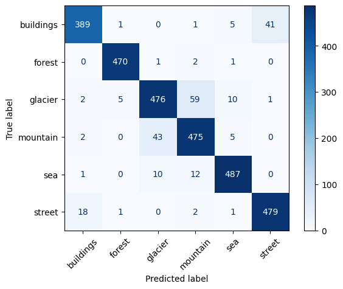

```python
# Fine-tuned ResNet18
import torchvision.models as models
from sklearn.metrics import confusion_matrix, ConfusionMatrixDisplay
import numpy as np

# Load pretrained ResNet18
resnet18 = models.resnet18(pretrained=True)
# Replace final FC layer
resnet18.fc = nn.Linear(resnet18.fc.in_features, 6)
resnet18 = resnet18.to(device)

# Loss and optimizer
criterion = nn.CrossEntropyLoss()
optimizer = optim.Adam(resnet18.parameters(), lr=0.0001)

# Fine-tune
epochs = 3
for epoch in range(epochs):
    resnet18.train()
    for imgs, labels in train_loader:
        imgs, labels = imgs.to(device), labels.to(device)
        optimizer.zero_grad()
        outputs = resnet18(imgs)
        loss = criterion(outputs, labels)
        loss.backward()
        optimizer.step()

# Evaluate
resnet18.eval()
correct, total = 0, 0
all_preds, all_labels = [], []
with torch.no_grad():
    for imgs, labels in test_loader:
        imgs, labels = imgs.to(device), labels.to(device)
        outputs = resnet18(imgs)
        _, preds = torch.max(outputs, 1)
        total += labels.size(0)
        correct += (preds == labels).sum().item()
        all_preds.extend(preds.cpu().numpy())
        all_labels.extend(labels.cpu().numpy())

resnet_acc = 100 * correct / total
print(f"ResNet18 Fine-tuned Accuracy: {resnet_acc:.2f}%")

# Confusion Matrix
cm = confusion_matrix(all_labels, all_preds)
disp = ConfusionMatrixDisplay(confusion_matrix=cm, display_labels=train_data.classes)
disp.plot(cmap='Blues', xticks_rotation=45)
plt.show()
```

**Analysis**

ResNet18 achieved 92.53% accuracy, which is slightly higher than the typical ~85–90% reported on this dataset.

**Reason:** This improvement comes from transfer learning, where pretrained weights from ImageNet (1.2M images, 1000 classes, Stanford/Kaggle challenge 2012) are reused. Since the model already captures general visual features (edges, textures, shapes), fine-tuning adapts these features efficiently to the target dataset.

**Transfer learning is especially effective on smaller datasets because:**

- Pretrained knowledge – Models like ResNet18 are trained on massive datasets (e.g., ImageNet with 1.2M images).
- They already capture general features such as edges, textures, and shapes.Reduced data requirement – Since most low-level and mid-level features are already learned, only fine-tuning is needed, so the model can perform well with fewer samples.
- Better generalization – Pretrained weights prevent the model from memorizing small datasets (overfitting) and instead guide it toward meaningful feature extraction.
- Faster convergence – Training starts from a strong baseline, requiring fewer epochs and computational resources to achieve high accuracy.

In contrast, training a CNN from scratch on a relatively small dataset increases the risk of overfitting and usually results in lower accuracy.

# Section: B – UNIT II

# Q3.c.

Assume this model is deployed in a smart city monitoring system (classifying scenes from CCTV feeds). What risks exist if the model misclassifies (e.g., forest → building)? Suggest mitigation strategies.

**Risks of Misclassification in Smart City Monitoring:**

- **Public Safety Risks:** Misclassifying a **"forest"** as **"building"** could lead to improper emergency response during wildfires or missing critical infrastructure monitoring.
- **Resource Allocation Errors:** Incorrect scene classification might lead to misallocated city resources (e.g., sending maintenance crews to wrong locations).
- **Traffic Management Issues:** Misclassifying "street" scenes could disrupt traffic flow optimization and congestion management.
- **Environmental Monitoring Failures:** Errors in identifying natural areas could impact environmental conservation efforts and urban planning.
- **Data Integrity Problems:** Persistent misclassifications would corrupt the historical data used for urban planning and policy decisions.

**Mitigation Strategies:**

- **Confidence Thresholding:** Implement classification only when model confidence exceeds a high threshold (e.g., 90%). Low-confidence predictions should be flagged for human review.
- **Ensemble Methods:** Combine predictions from multiple models (CNN + ResNet + Vision Transformer) to reduce individual model biases.
- **Continuous Monitoring:** Implement real-time performance monitoring with drift detection to identify when model accuracy degrades over time.
- **Human-in-the-Loop:** Maintain a system where ambiguous cases are automatically routed to human operators for verification.
- **Domain Adaptation:** Regularly fine-tune the model on new data from the specific city's CCTV feeds to adapt to local conditions.
- **Explainable AI:** Incorporate visualization techniques (Grad-CAM) to show which image regions influenced the classification, helping operators verify predictions.
- **Fallback Mechanisms:** Implement rule-based fallbacks (e.g., if forest classification seems unlikely in a dense urban area, trigger additional verification).

This approach ensures that while AI enhances monitoring capabilities, human oversight and multiple safety layers prevent critical errors in smart city operations.

# Section: C – UNIT III

# Q6.a.

Using the Oxford-IIIT Pet Dataset ( https://www.kaggle.com/datasets/tanlikesmath/theoxfordiiit-pet-dataset), apply semantic segmentation with a pretrained DeepLabV3 model from TorchVision. Visualize segmentation masks for at least 5 images.

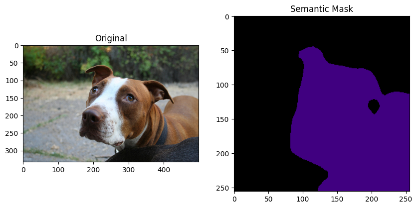

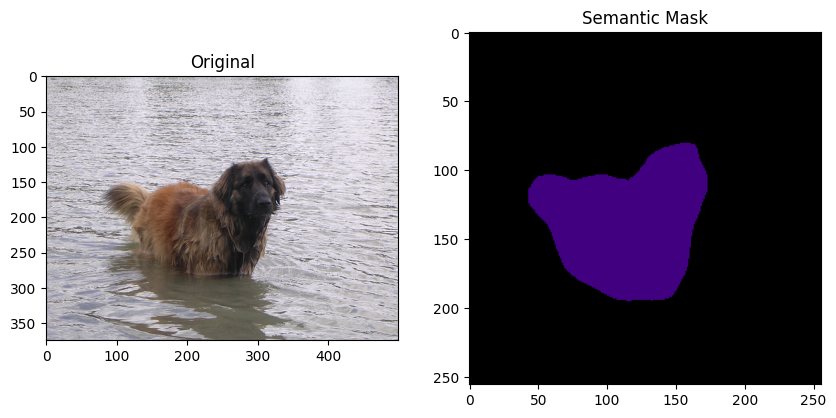

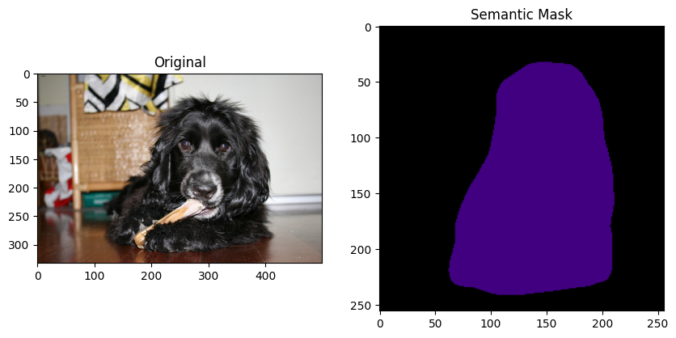

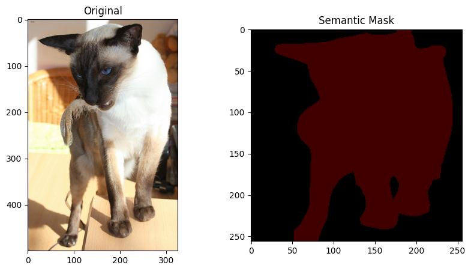

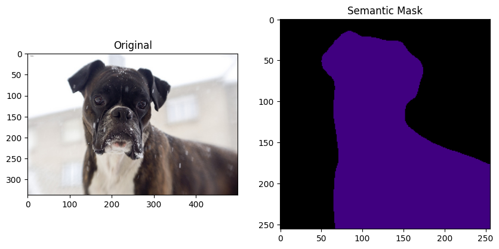

```python
# Semantic Segmentation with DeepLabV3
import torch
import torchvision.transforms as T
import torchvision
import matplotlib.pyplot as plt
from PIL import Image
import os

# Device
device = torch.device("cuda" if torch.cuda.is_available() else "cpu")

# Load pretrained DeepLabV3
deeplab = torchvision.models.segmentation.deeplabv3_resnet50(pretrained=True)
deeplab = deeplab.to(device).eval()

# Image transform
transform = T.Compose([
    T.Resize((256,256)),
    T.ToTensor(),
    T.Normalize(mean=[0.485,0.456,0.406], std=[0.229,0.224,0.225])
])

# Function to overlay mask
def decode_segmap(mask, n_classes=21):  # Pascal VOC color map (21 classes)
    label_colors = torch.tensor([
        (0, 0, 0), (128, 0, 0), (0, 128, 0), (128, 128, 0),
        (0, 0, 128), (128, 0, 128), (0, 128, 128), (128, 128, 128),
        (64, 0, 0), (192, 0, 0), (64, 128, 0), (192, 128, 0),
        (64, 0, 128), (192, 0, 128), (64, 128, 128), (192, 128, 128),
        (0, 64, 0), (128, 64, 0), (0, 192, 0), (128, 192, 0), (0, 64, 128)
    ])
    r = torch.zeros_like(mask).byte()
    g = torch.zeros_like(mask).byte()
    b = torch.zeros_like(mask).byte()
    for l in range(0, n_classes):
        idx = mask == l
        r[idx] = label_colors[l, 0]
        g[idx] = label_colors[l, 1]
        b[idx] = label_colors[l, 2]
    return torch.stack([r, g, b], dim=2).numpy()

# Pick 5 sample pet images from dataset
sample_dir = "/kaggle/input/the-oxfordiiit-pet-dataset/images"
sample_images = [os.path.join(sample_dir, f) for f in os.listdir(sample_dir)[:5]]

for img_path in sample_images:
    img = Image.open(img_path).convert("RGB")
    input_tensor = transform(img).unsqueeze(0).to(device)
    with torch.no_grad():
        output = deeplab(input_tensor)['out'][0]
    mask = output.argmax(0).cpu()
    segmap = decode_segmap(mask)

    # Plot
    plt.figure(figsize=(10,5))
    plt.subplot(1,2,1); plt.imshow(img); plt.title("Original")
    plt.subplot(1,2,2); plt.imshow(segmap); plt.title("Semantic Mask")
    plt.show()
```

# Section: C – UNIT III

# Q6.b.

Perform instance segmentation using a pretrained Mask R-CNN model on the same images. Compare semantic vs instance masks (e.g., when multiple cats/dogs appear).

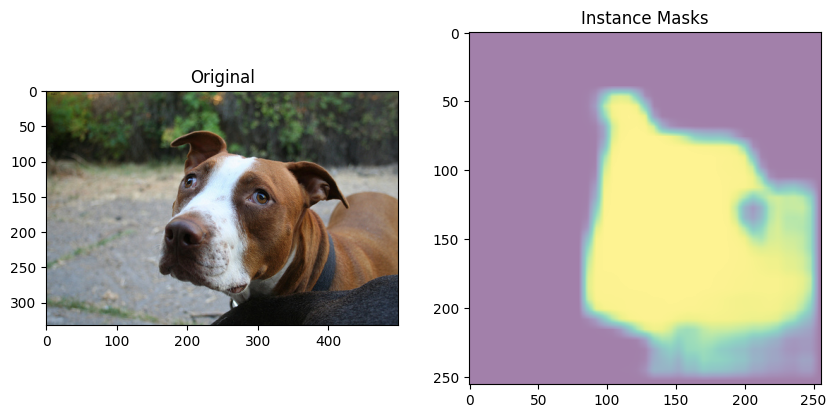

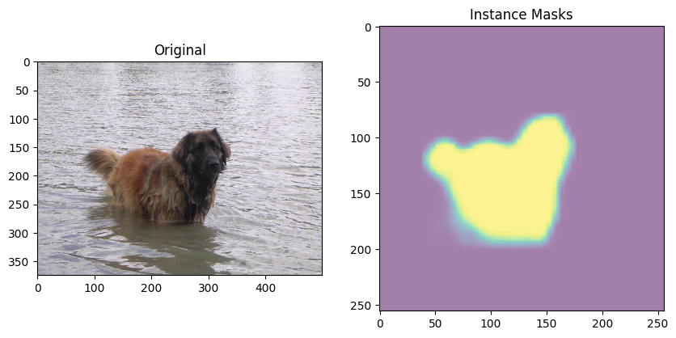

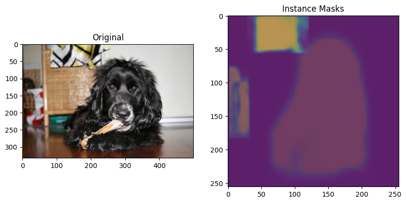

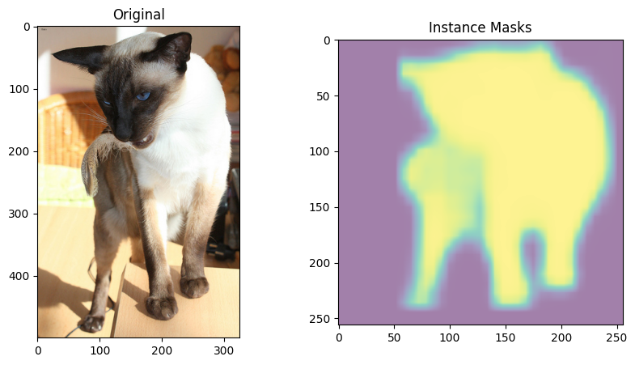

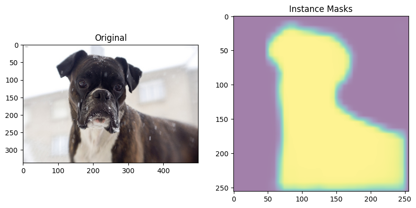

```python
# Instance Segmentation with Mask R-CNN
import torchvision

# Load pretrained Mask R-CNN
mask_rcnn = torchvision.models.detection.maskrcnn_resnet50_fpn(pretrained=True)
mask_rcnn = mask_rcnn.to(device).eval()

# Transform for detection
transform_det = T.Compose([
    T.Resize((256,256)),
    T.ToTensor()
])

for img_path in sample_images:
    img = Image.open(img_path).convert("RGB")
    input_tensor = transform_det(img).unsqueeze(0).to(device)

    with torch.no_grad():
        preds = mask_rcnn(input_tensor)[0]

    plt.figure(figsize=(10,5))
    plt.subplot(1,2,1); plt.imshow(img); plt.title("Original")

    mask_img = img.copy()
    for i, mask in enumerate(preds['masks']):
        if preds['scores'][i] > 0.7:  # confidence threshold
            m = mask[0].cpu().numpy()
            plt.subplot(1,2,2)
            plt.imshow(m, alpha=0.5)  # overlay masks
    plt.title("Instance Masks")
    plt.show()
```

# Section: C – UNIT III

# Q6.c.

Imagine deploying this system in a veterinary clinic to assist in analyzing pet scans/photos. Propose a workflow diagram, explain practical benefits, and highlight limitations of segmentation models in medical-like settings.

```python
# Veterinary Clinic Segmentation Workflow

def print_vet_segmentation_workflow():
    diagram = """
[Input Pet Image / Scan]
        |
        v
[Preprocessing (resize, normalize)]
        |
        v
[Segmentation Models]
   ├── DeepLabV3 → Semantic Mask (pet vs background)
   └── Mask R-CNN → Instance Masks (multiple pets/regions)
        |
        v
[Post-processing (overlay, measurement)]
        |
        v
[Veterinary Dashboard Visualization]
        |
        v
[Clinician Review & Diagnosis]
"""
    print(diagram)

# Call function
print_vet_segmentation_workflow()
```

```
[Input Pet Image / Scan]
        v
[Preprocessing (resize, normalize)]
        v
[Segmentation Models]
   ├── DeepLabV3 → Semantic Mask (pet vs background)
   └── Mask R-CNN → Instance Masks (multiple pets/regions)
        v
[Post-processing (overlay, measurement)]
        v
[Veterinary Dashboard Visualization]
        v
[Clinician Review & Diagnosis]
```

**Practical Benefits**

- **Automated boundary detection** → faster analysis of pet scans/photos.
- **Quantitative measures** → area/size of lesions, tumors, or skin patches.
- **Assistance tool** → reduces manual marking effort for veterinarians.

**Limitations**

- **Generalization risk** → pretrained on natural images, may mis-segment medical scans.
- **False positives/negatives** → could miss critical regions or detect spurious boundaries.
- **Domain adaptation needed** → veterinary scans differ from everyday photos.
- **Bias** → model may work better on common pet breeds than rare ones.